# Variational Inference for SC RNAseq data

Panagiotis Papasaikas

2021-08-19

```r
suppressPackageStartupMessages({
system("pipenv --python 3.8")
venv <- system("pipenv --venv", inter = TRUE)
reticulate::use_virtualenv(venv, required = TRUE)
library(tensorflow)
install_tensorflow(version= '2.2.0-gpu')
library(keras)
library(Matrix)
library(SingleCellExperiment)
library(Rtsne)
library(rsvd)
library(RColorBrewer)
})
```

# Load the pre-processed dataset

The dataset that we will use is a composite dataset of three independent 10x runs originating from three different labs. It consists of 9288 mammary epithelial cells, sequenced using 10x Genomics technology, which has already been pre-filtered to include only cells that are assigned unambiguously to one of three major cell types: luminal progenitors, luminal mature and basal.

Features have also been preselected to include only those genes that are present and variable in all three datasets. Next, we load the preprocessed dataset and have a first look at the composition of the dataset:

```r
## Download the data and set row names to gene symbols whenever possible
sce <- readRDS(gzcon(url("https://ppapasaikas.github.io/SC_datasets/Data/SCE_MammaryGland.rds?raw=true")))
#Subsample cells to speed up processing and, most importantly, later-on model training:
#set.seed(42)
#n=4000
#sce <- sce[, sample(1:ncol(sce), n )  ]
## Dataset composition per cell type and study:
table(colData(sce)$study , colData(sce)$cell.class)
```

```
##
##       luminal_progenitor basal luminal_mature
##   spk               1097   475           1043
##   vis                694  1257           1096
##   wal                729   780           2117
```

Let’s also take a look at a “standard” projection of the dataset

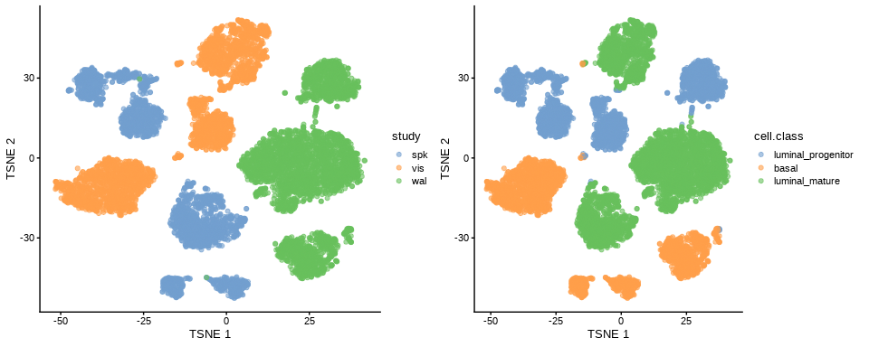

```r
# We first normalize all cells for library size.
assays(sce )[["lognorm"]] <- log2(sweep( counts(sce),2,sce$library_size ,FUN="/")*1e4 +1)
reducedDim(sce, "PCA" )  <- rsvd::rpca(t( assay(sce,"lognorm") ),k=32,retx=TRUE,center=TRUE,scale=FALSE)$x
reducedDim(sce, "TSNE" ) <- Rtsne( reducedDim(sce,"PCA"), perplexity = 30, initial_dims=32, pca=FALSE, theta=0.3)$Y #~5"-20" run time

cowplot::plot_grid(scater::plotTSNE(sce, colour_by = "study" ),
                   scater::plotTSNE(sce, colour_by = "cell.class"))
```

# Preparing the data for input.

We will split the data 80-20 to a training and validation set.

In addition, the input to the model has to be in the form of a 2D array with the samples in the rowsand features in the columns.

Of course in this case our 2D array is (also) a matrix. However in the general case where every sample is a feature vector of > *1D* the data should be shaped as a multidimensional array with the samples in the 1st dimension.

```r
combined.df.filtered <- as.matrix(assays(sce )[["lognorm"]] )

####### Splitting in training and validation data, converting to array
set.seed(1)
holback.fraction=0.2
holdback.samples=sample(1:ncol(sce),round(holback.fraction*ncol(sce)) )

##### Training Data:
M=combined.df.filtered[,-holdback.samples]
sc_train_x=array(M, dim= c(dim(M)[1], prod(dim(M)[-1]))) # convert to an array
sc_train_x=t(sc_train_x)                                 #Need to transpose before passing to the model
rm(M)


##### Validation Data:
M=combined.df.filtered[,holdback.samples]
sc_test_x=array( M, dim= c(dim(M)[1], prod(dim(M)[-1]))) # convert to an array
sc_test_x=t(sc_test_x)                                   # Need to transpose before passing to the model
rm(M)
###################################################################
```

# Define the variational autoencoder model

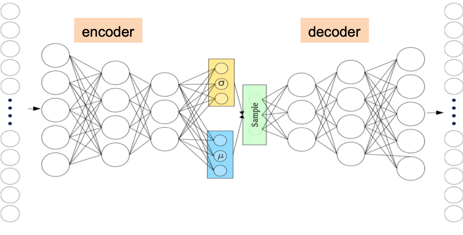

```r
##### Sparse variational autoencoder model
# Ensure compatibility with both TF2 nd TF1:
if (tensorflow::tf$executing_eagerly())
  tensorflow::tf$compat$v1$disable_eager_execution()

# Parameters --------------------------------------------------------------
neck <- 32L # Latent (bottleneck) dimension
drop_rate=0.2 #
gene_dim <- ncol(sc_train_x)  #Number of features (genes) in your dataset
latent_dim <- neck
epsilon_std <- 0.8  ##Standard deviation of the prior latent distribution (vanilla =1)
var_prior <- epsilon_std**2
log_var_prior <- log(var_prior)
kl_weight=0.1   #Weight for the Kulllback-Leibler divergence loss (vanilla =1 )

# Encoder definition  (using the functional API) :
x <- layer_input(shape = c(gene_dim),name="gene_input")
h <- layer_dense(x, 8 * neck, activation = "elu")
h <- layer_dropout(h, rate = drop_rate)
h <- layer_dense(h, 4 * neck,activation="elu")
h <- layer_dropout(h, rate = drop_rate)
h <- layer_dense(h, 2 * neck, activation = "elu")
h <- layer_dropout(h, rate = drop_rate)
z_mean <- layer_dense(h, latent_dim)
z_log_var <- layer_dense(h, latent_dim)

#### Sampling from the latent space:
sampling <- function(arg){
    z_mean <- arg[, 1:(latent_dim)]
    z_log_var <- arg[, (latent_dim + 1):(2 * latent_dim)]
    epsilon <- K$random_normal(
        shape = c(K$shape(z_mean)[[1]]),
        mean=0.,
        stddev=epsilon_std
    )
    z_mean + K$exp(z_log_var/2)*epsilon
}

# Lambda layer for variational sampling:
z <- layer_concatenate(list(z_mean, z_log_var)) %>%
    layer_lambda(sampling)


# we instantiate the decoder separately so as to reuse it later
decoder_h <- keras_model_sequential()
decoder_h %>%
    layer_dense(units= 2 * neck,activation="elu") %>% #
    layer_dropout(rate = drop_rate) %>%
    layer_dense(units= 4 * neck,activation="elu") %>%
    layer_dropout(rate = drop_rate) %>%
    layer_dense( 8 * neck, activation = "elu") %>%
    layer_dropout(rate = drop_rate)

decoder_mean <- layer_dense(units = gene_dim, activation = "relu")
h_decoded <- decoder_h(z)
x_decoded_mean <- decoder_mean(h_decoded)

# end-to-end autoencoder (again notice the use of the functional API):
vae <- keras_model(x, x_decoded_mean)

# encoder, from inputs to latent space, also using the functional API:
encoder <- keras_model(x, z_mean)

# generator, from latent space to reconstructed inputs
decoder_input <- layer_input(shape = latent_dim)
h_decoded_2 <- decoder_h(decoder_input)
x_decoded_mean_2 <- decoder_mean(h_decoded_2)
generator <- keras_model(decoder_input, x_decoded_mean_2)
```

Next we define our loss function as well as any custom accuracy functions we wish to keep track of during training

```r
vae_loss <- function(x, x_decoded_mean){
    reconstruction_loss  <-  loss_mean_squared_error(x, x_decoded_mean)
    kl_loss <- -kl_weight*0.5*K$mean(1 + z_log_var-log_var_prior - K$square(z_mean)/var_prior - K$exp(z_log_var)/var_prior, axis = -1L)  # More general formula
    reconstruction_loss + kl_loss
}


#### Custom correlation function to keep track of.
#### Notice that all mathematical operation NEED to be performed using the Keras backend (e.g K$mean):
cor_metric <- function(y_true, y_pred) {
    x = y_true
    y = y_pred
    xm = x-K$mean(x)
    ym = y-K$mean(y)
    r_num = K$sum(tf$multiply(xm,ym))
    r_den = K$sqrt(tf$multiply(K$sum(K$square(xm)), K$sum(K$square(ym))))
    r = r_num / r_den
    r = K$maximum(K$minimum(r, 1.0), -1.0)
    return (K$square(r))
}
```

# Model compilation

We are now going to compile the specified model. There are two required arguments that need to be specified for model compilation: The **loss function** and the **optimizer**.

Whereas the *loss function* specifies our training objective the *optimizer* specifies the specific algorithmic machinery by which the parameters of the model will be updated. Almost all optimizers are variants of the *gradient descent* algorithm that tries to minimize a function (in this case our loss) by moving towards the steepest descent as this is estimated by the negative gradient. Here we will use the `adam` optimizer, which belongs to the subfamily of “*adaptive moment estimation*” optimizers. These optimizers are based on the intuition that not all parameters need to change with the same rate. One can use the recent gradients to adjust learning rates of individual parameters in order to achieve faster convergence.

For more details on the different optimizers option provided by keras you can check: [“keras optimizers”](https://keras.io/api/optimizers/adam/)

For more details on the adam optimizer see: [“adam optimization”](https://machinelearningmastery.com/adam-optimization-algorithm-for-deep-learning/)

```r
#compiling the defined model with metric = accuracy and optimiser adam.
opt <-  optimizer_adam(lr =0.001,amsgrad = TRUE)#
vae %>% compile(
  loss = vae_loss,
  optimizer = opt,
  metrics = custom_metric("cor",cor_metric)
)
```

# Model training (fitting)

In this next step we will fit the VAE model that we have compiled.

In addition we will make use of an *early-stopping* callback in order to terminate training when no further progress is observed.

Finally we will illustrate (but not actually make use of because of renku limitations) the callback for starting tensorboard in order to conveniently keep track of of the training process

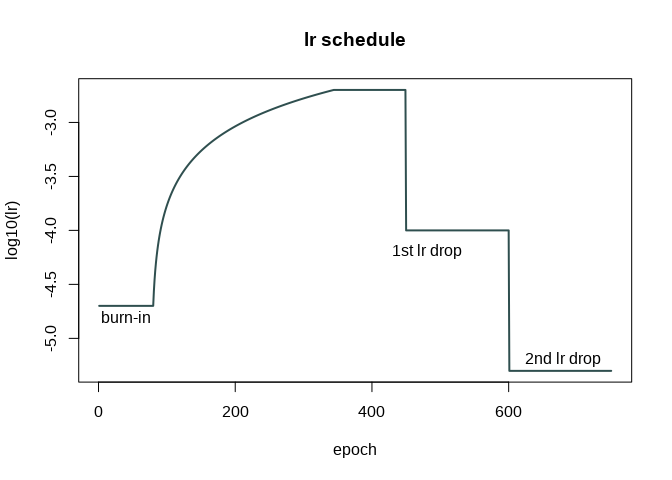

```r
##### Learning rate scheduler:
burn_in.nepochs <- 80
burn_in_lr <- 2e-5
batch_size <- 512

 lr_schedule <- function(epoch, current_lr) {
   if (epoch <= burn_in.nepochs ) lr <- burn_in_lr
   else if (epoch < 450) lr <- min (2e-3, burn_in_lr + 1.5e-4 * ( (epoch-burn_in.nepochs)/20) )#Increase lr linearly up to 2e-3
   else if (epoch > 600 ) {lr <- 5e-6 } #Second LR drop  (Cool down)
   else {lr <- 1e-4} #First LR drop
   return(lr)
 }

lr_sch <- callback_learning_rate_scheduler(lr_schedule)

# Visualize the learnign rate schedule:
plot( 1:750, log10(  sapply (1:750, function(x) lr_schedule(x) ) )
          , type="l", col="darkslategray", xlab="epoch", ylab="log10(lr)", lwd=2, main="lr schedule")
text( c(40,480,680), c(-4.8,-4.2,-5.2),c("burn-in","1st lr drop","2nd lr drop") )
```

```r
##### Early stopping callback:
early_stopping <- callback_early_stopping(monitor = "val_loss", min_delta = 0,
                                          patience = 125, verbose = 0, mode = "auto",
                                          baseline = NULL, restore_best_weights = TRUE)
```

```r
##### Tensorboard callback (do not execute):
indir <- "/Users/papapana/Desktop/XENON/papapana/DEEP_LEARNING/Autoencoders/BatchCor_paper" # When running locally
log_dir <-  paste0(indir,"/logs/run_exercise_DGNs/")
system(paste0 ("rm -rf ", log_dir, "/*")  )
system("pkill tensorboard")
#options(browser = function(url) browseURL(url, browser = "/usr/bin/firefox")) # When running on xenon
options(browser = function(url) browseURL(url, browser ="/usr/bin/open"  ))    # When running locally (MacOS)
tensorboard( log_dir,  launch_browser = TRUE )
tnsrb <- callback_tensorboard( log_dir )
```

```r
nepochs=1000 #
######  Fit the model using also our specified callbacks for scheduling and early stopping:
history <- vae %>% fit(
    x=sc_train_x,
    y=sc_train_x,
    shuffle = TRUE,
    epochs = nepochs,
    batch_size = batch_size,
    validation_data=list(sc_test_x,sc_test_x),
    callbacks = list(early_stopping, lr_sch )
    #callbacks = list(tnsrb, early_stopping, lr_sch )
)
#saveRDS(history, file="Data/MG_complete_VAE_history.rds")
#filepath <- "Trained_Models/MG_complete_VAE_weights.hdf5"
#save_model_weights_hdf5(vae, filepath)
```

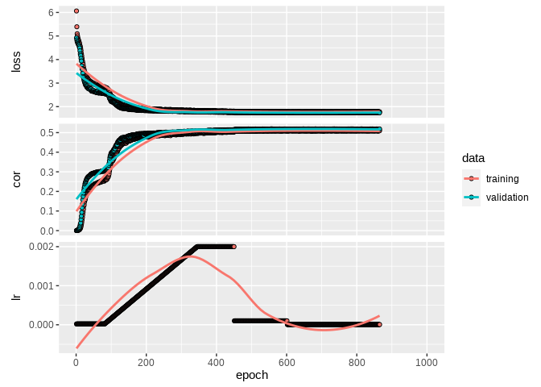

```r
history <- readRDS("Data/MG_complete_VAE_history.rds")
plot(history)
```

# Decoded output, latent representation and inference

We now have in our hands a trained VAE for our dataset. What is it good for?

- The **decoded output** is a denoised version of our data. You can view the decoded output as a “cleaned-up” dataset where drop-outs have been imputed, outliers have been corrected for and measurement imperfections (including sampling variance) have been ironed out. As we will see, this has a dramatic effect on the **mean-variance profile** of our decoded dataset.
- The **latent output** is in itself a (highly non-linear) reduced dimension representation of our dataset. That means we can use it for visualization or to summarize specific subsets of our data.
- More importantly the latent representation is an estimation of the **manifold** that gives rise to our data. This allows us in principle to sample new observations from the complete area or specific regions of the manifold and to perform **inference**. For example we can “morph” cells from one type to another or even register and study all intermediate steps in this “morphing” process.

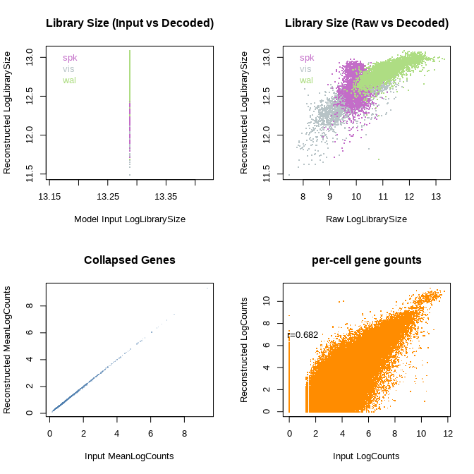

```r
########################################################################################################
vae %>% load_model_weights_hdf5("trained_models/MG_complete_VAE_weights.hdf5")

palettes <- readRDS("Data/distinct_palettes.rds")

##### Run on the combined select dataset (train + validation):
study_annot <- sce$study
ct_annot <- sce$cell.class
combined.annot <- paste(sce$study,sce$cell.class,sep="_")

M <- combined.df.filtered
sc_x <- array(M, dim= c(dim(M)[1], prod(dim(M)[-1]))) # convert to an array
sc_x <- t(sc_x)                                       #Need to transpose before passing to the model
rm(M)

latent_output <- predict(encoder, list(gene_input=sc_x))
decoded_data <- predict( generator,  latent_output)

decoded_data.linear <- 2^decoded_data-1
sc_x.linear <- 2^sc_x-1

colsfact <- as.factor(sce$study)
mycols <- palettes[[nlevels(colsfact)]]
cols <- mycols[colsfact]

### Several diagnostic plots:
par(mfrow=c(2,2))
plot(log2(rowSums(sc_x.linear)),log2(rowSums(decoded_data.linear)),pch=".",cex=2.5,col=cols,
     xlab="Model Input LogLibrarySize",ylab="Reconstructed LogLibrarySize",main="Library Size (Input vs Decoded)")
legend("topleft",bty ="n", text.col= mycols, legend=levels(colsfact))

plot(log2(colSums(counts(sce))),log2(rowSums(decoded_data.linear)),pch=".",cex=2.5,col=cols,
     xlab="Raw LogLibrarySize",ylab="Reconstructed LogLibrarySize",main="Library Size (Raw vs Decoded)")
legend("topleft",bty ="n", text.col= mycols, legend=levels(colsfact))

plot(colMeans(sc_x),colMeans(decoded_data),pch=".",cex=2,col="#5080B055",
     xlab="Input MeanLogCounts",ylab="Reconstructed MeanLogCounts",main="Collapsed Genes")

s=sample(1:nrow(sc_x),500)
mean.cor = mean(sapply(1:nrow(decoded_data[s,]),function(x) {cor(sc_x[x,],decoded_data[x,])}   ))

plot(as.vector((sc_x[s,])), as.vector((decoded_data[s,])),pch=".", cex=2,col="darkorange", #
     xlab="Input LogCounts",ylab="Reconstructed LogCounts",main="per-cell gene gounts")
text(1,7,paste("r=",round(mean.cor,3),sep=""))
```

We will now examine the **mean-variance** profile of the decoded output and compare it to the corresponding profile of the input data.

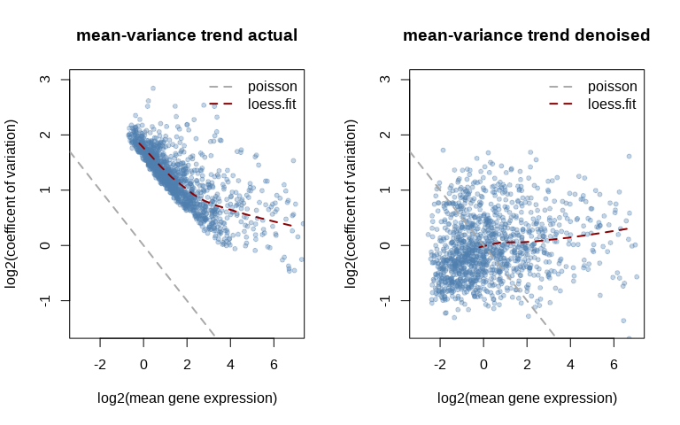

```r
############################### Mean Variance plots:  ###############################
pc <- 0.001 #pseudocount
zeroes <- which(colSums(sc_x.linear) < quantile(colSums(sc_x.linear),0.01) )

mean_GE <- colMeans(sc_x.linear[,-zeroes] + pc )
gene_cv <- apply(sc_x.linear[,-zeroes], 2, function(x) sd(x+pc)/mean(x+pc ) )
mean_GE_decod <- colMeans(decoded_data.linear[,-zeroes] +pc )
gene_cv_decod <- apply(decoded_data.linear[,-zeroes], 2, function(x) sd(x+pc)/mean(x+pc ) )

#Log transform expression and cv:
X1 <- log2(mean_GE)
Y1 <- log2(gene_cv+pc )
X1_decod <- log2(mean_GE_decod)
Y1_decod <- log2(gene_cv_decod+pc  )
Y1_decod[Y1_decod < 1 & X1_decod < -7 ] <- 1

#linear fit of log(cv) as a function of log(gene expression):
use_t <- which(X1<quantile(X1,0.95) &  X1>quantile(X1,0.1))
use_d <- which(X1_decod<quantile(X1_decod,0.95) &  X1_decod>quantile(X1_decod,0.1))
m <- lm(Y1[use_t] ~ X1[use_t])
m_decod <- lm(Y1_decod[use_d] ~ X1_decod[use_d])

#Loess Fit of log(cv) as a function of log(gene expression):
loess <- loess(Y1[use_t] ~ X1[use_t],control=loess.control(surface="direct"),span=0.5, degree=1)
loess_decod <- loess(Y1_decod[use_d] ~ X1_decod[use_d],control=loess.control(surface="direct"),span=0.5, degree=1)
xvar <- seq( min(X1)+0.5, max(X1)-2.5,0.5   )
sm <- predict(loess,xvar)
sm_decod <- predict(loess_decod,xvar)

par(mfrow=c(1,2))
xlim=c(-3,7)
ylim=c(-1.5,3)

##scatterplot of log(cv) as a function of log(mean expression):
plot(X1,Y1,xlab="log2(mean gene expression)",ylab="log2(coefficent of variation)" ,main="mean-variance trend actual",pch=19,col="#5080B055",cex=0.7,xlim=xlim,ylim=ylim )
lines(sm,x= xvar,col="darkred",lty=2,lwd=2) # Loess fit
abline(0,-0.5,col="darkgrey",lwd=2,lty=2) # Slope in m-v trend according to poisson distribution:
legend("topright",legend = c("poisson","loess.fit"),lty=2,lwd=2,bty="n",col=c("darkgrey","darkred"))

plot(X1_decod,Y1_decod,xlab="log2(mean gene expression)",ylab="log2(coefficent of variation)" ,main="mean-variance trend denoised",pch=19,col="#5080B055",cex=0.7,xlim=xlim,ylim=ylim  )
lines(sm_decod,x= xvar,col="darkred",lty=2,lwd=2) # Loess fit
abline(0,-0.5,col="darkgrey",lwd=2,lty=2) # Slope in m-v trend according to poisson distribution:
legend("topright",legend = c("poisson","loess.fit"),lty=2,lwd=2,bty="n",col=c("darkgrey","darkred"))
```

## Batch correction using latent arithmetic

Here we will show a first example of using our learned latent space for inference. Specifically we will correct for batch-specific effects by decomposing the variance in the latent space:

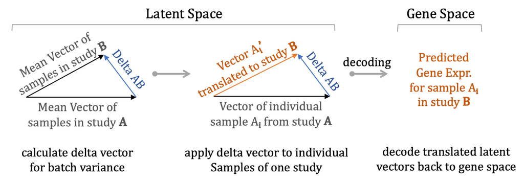

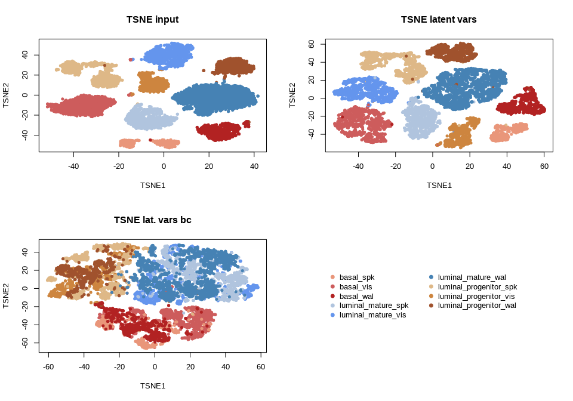

```r
########## Latent arithmetic operations to correct for batch :
# For each batch calculate the mean latent vector. Apply lv arithmetic to move all batches to an arbitrary (e.g most populous) reference batch
ref_batch <- names(which.max(table(study_annot))) # Set as reference batch the most populous study
idx_ref <- which(study_annot == ref_batch)

latent_output_bc <- latent_output
batch_lv  <- list()
Delta_lv <- matrix(0,nrow = length(unique(study_annot)), ncol=ncol(latent_output) )
rownames(Delta_lv) <- unique(study_annot)
batch_lv[[ref_batch]] <- colMeans(latent_output[idx_ref ,])

for (b in setdiff( unique(study_annot),ref_batch )  ) {
idx <- which(study_annot == b)
batch_lv[[b]] <- colMeans(latent_output[idx,])   # Calculate mean latent vectors for the batch
Delta_lv[b, ] <- batch_lv[[b]] - batch_lv[[ref_batch]]  # Calculate batch lv delta from reference batch
latent_output_bc[idx,] <- sweep(latent_output_bc[idx,], 2, Delta_lv[b, ]   ) # Create a new latent output  that is corrected for batch
}

decoded_data_bc <- predict( generator,  latent_output_bc  ) #New decoded data that are corrected for batch



########### Cell projections ###########
annot <- study_annot
annot <- paste0(ct_annot,"_",study_annot) #


#reducedDim(sce, "PCA_decod" )  <- rpca(decoded_data, k=32, retx=TRUE, center=TRUE, scale=FALSE)$x
#reducedDim(sce, "PCA_decod_bc" ) <- rpca(decoded_data_bc ,k=32, retx=TRUE, center=TRUE, scale=FALSE)$x
reducedDim(sce, "vae_latent" ) <- latent_output
reducedDim(sce, "vae_latent_bc" ) <- latent_output_bc


#reducedDim(sce, "TSNE_PCA_decod" ) <- Rtsne(  reducedDim(sce,"PCA_decod"), perplexity = 30, initial_dims=32, pca=FALSE, num_threads =8, theta=0.3)$Y
#reducedDim(sce, "TSNE_PCA_decod_bc" ) <- Rtsne(reducedDim(sce,"PCA_decod_bc"), perplexity = 30, initial_dims=32, pca=FALSE, num_threads =8,   theta=0.3)$Y
reducedDim(sce, "TSNE_vae_latent" ) <- Rtsne( reducedDim(sce,"vae_latent"), perplexity = 30, initial_dims=32, pca=FALSE, num_threads=8,   theta=0.3)$Y
reducedDim(sce, "TSNE_vae_latent_bc" ) <- Rtsne( reducedDim(sce,"vae_latent_bc"), perplexity = 30, initial_dims=32, pca=FALSE, num_threads=8,  theta=0.3)$Y



############ PLOTTING
palette <- c("DarkSalmon","IndianRed","Firebrick","LightSteelBlue","CornFlowerBlue","SteelBlue","Burlywood","Peru","Sienna")

names(palette) <- names( table( annot )  )
cols <- palette[  annot  ]

TSNEin <- reducedDim(sce,"TSNE")
#TSNEdc <- reducedDim(sce,"TSNE_PCA_decod")
#TSNEdc_bc <- reducedDim(sce,"TSNE_PCA_decod_bc")
TSNElv <- reducedDim(sce,"TSNE_vae_latent")
TSNElv_bc <- reducedDim(sce,"TSNE_vae_latent_bc")


par(mfrow=c(2,2))
plot(TSNEin[,1],TSNEin[,2],pch=19,col=cols,xlab="TSNE1",ylab="TSNE2",cex=0.7,main="TSNE input")
#plot(TSNEdc[,1],TSNEdc[,2],pch=19,col=cols,xlab="TSNE1",ylab="TSNE2",cex=0.7,main="TSNE decoded")
plot(TSNElv[,1],TSNElv[,2],pch=19,col=cols,xlab="TSNE1",ylab="TSNE2",cex=0.7,main="TSNE latent vars")
plot(TSNElv_bc[,1],TSNElv_bc[,2],pch=19,col=cols,xlab="TSNE1",ylab="TSNE2",cex=0.7,main="TSNE lat. vars bc")
#plot(TSNEdc_bc[,1],TSNElv_bc[,2],pch=19,col=cols,xlab="TSNE1",ylab="TSNE2",cex=0.7,main="TSNE decoded bc")
plot.new()
legend("left",bty ="n", pch=19, col= palette, legend=names(palette) , ncol=2,cex=1 , text.width=0.4)
```

# Inference continued: Out-of-sample prediction

Now we implement a second example of latent arithmetic-based inference. In this case we will assume we were missing one the cell types (luminal progenitors) in one of the three studies (wal). Following the same rational of decomposing variance sources in latent space we will then predict the profile of the missing cell type in the target study:

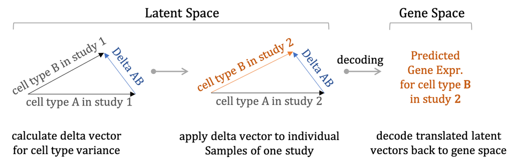

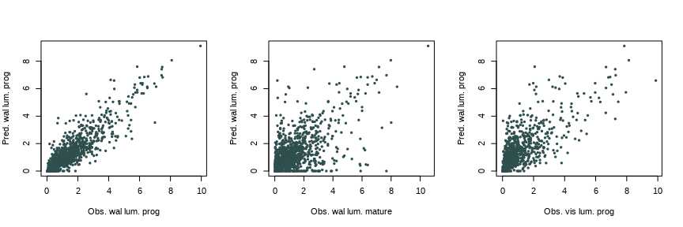

```r
#We will use a model that was trained on data that never saw wal luminal progenitor cells:
vae %>% load_model_weights_hdf5("trained_models/MG_leavout_wallp_VAE_weights.hdf5")
latent_output <- predict(encoder, list(gene_input=sc_x))


########## Latent arithmetic operations for out-of-sample prediction :
# In one the two fully available studies calculate the delta between the luminal progenitors and the other two cell types:
# Here we will use the vis study (though we could instead or in addition use the spk study):

#Deltas:
D_lp_bs.vis <- colMeans(latent_output[sce$study=="vis" & sce$cell.class=="luminal_progenitor",]) - colMeans(latent_output[sce$study=="vis" & sce$cell.class=="basal",])
D_lp_lm.vis <- colMeans(latent_output[sce$study=="vis" & sce$cell.class=="luminal_progenitor",]) - colMeans(latent_output[sce$study=="vis" & sce$cell.class=="luminal_mature",])

#Shift latent vector of wal cell types in the luminal progenitor direction:
pred1_lp.wal <- colMeans(latent_output[sce$study=="wal" & sce$cell.class=="basal",] )+ D_lp_bs.vis
pred2_lp.wal <- colMeans(latent_output[sce$study=="wal" & sce$cell.class=="luminal_mature",] ) + D_lp_lm.vis

#Take the average of the two predictions and decode:
pred_lp.wal <- 0.5 * (pred1_lp.wal + pred2_lp.wal)
pred_decoded_lp.wal <- predict( generator,  t(pred_lp.wal)   )


par(mfrow=c(1,3))
plot( colMeans(sc_x[sce$study=="wal" & sce$cell.class=="luminal_progenitor",]), pred_decoded_lp.wal[1,],
      pch=19,cex=0.5, col="darkslategrey",xlab="Obs. wal lum. prog", ylab="Pred. wal lum. prog"   )
plot( colMeans(sc_x[sce$study=="wal" & sce$cell.class=="luminal_mature",]), pred_decoded_lp.wal[1,],
      pch=19,cex=0.5, col="darkslategrey",xlab="Obs. wal lum. mature", ylab="Pred. wal lum. prog"   )
plot( colMeans(sc_x[sce$study=="vis" & sce$cell.class=="luminal_progenitor",]), pred_decoded_lp.wal[1,],
      pch=19,cex=0.5, col="darkslategrey",xlab="Obs. vis lum. prog", ylab="Pred. wal lum. prog"   )
```